# Machine Learning Course Project

2023-12-18

# Classification of Movement Using Raw Accelerometer Data

## Introduction

Our objective is to find a machine learning algorithm that accurately predicts which kind (out of 4 incorrect and 1 correct) of movement type is being performed, based on various raw accelerometer and gyroscope data from on-body band sensors.

## Cleaning/Focusing the Data

```r
##downloading and reading files
url<-"https://d396qusza40orc.cloudfront.net/predmachlearn/pml-training.csv"
url2<-"https://d396qusza40orc.cloudfront.net/predmachlearn/pml-testing.csv"
download.file(url, destfile="train.csv")
train<-read.csv("train.csv")
download.file(url2, destfile="test.csv")
test<-read.csv("test.csv")
```

This data set is challenging because it is missing the calculated features the researchers used for their models, and is a collection of overlapping, shifting windows of time. There is also some multicolinearity in the information (x,y, and z axes for multiple different measurements), though, in the end, I went with a model with no PCA pre-processing because it didn’t improve the accuracy very much. Luckily, we don’t have to forecast, as the purpose is to classify the movements, not predict which ones are coming next.

I also chose to naively approach the model instead of trying to make my own calculated features, only taking out variables that were repeats or not likely to be important. There are also mismatches between what variables were included in the testing set and what was in the training set, and some variables that were included in the testing set that were fully NA (all the summary columns with standard deviation, mean, etc). Figuring those variables wouldn’t be important in the final model—otherwise they would have been given—I took those out. Finally, I also removed from the training set the summary rows (“new_window”==“yes”), since it was redundant information.

```r
##subsetting so train set has all of the same variables as test, without NA columns;removing summary rows and summary variables (avg, std, etc)
test_small<-test[,colSums(is.na(test))==0]
same<-intersect(names(test_small), names(train))
library(dplyr)
train_small<-train%>%select(all_of(same), 160)%>%rename("outcome"="classe")%>%filter(new_window=="no")
train_small$outcome<-as.factor(train_small$outcome)
train_smaller<-train_small%>%select(-X,-cvtd_timestamp,-new_window,-num_window)
```

## Choosing a Model

Given that our task is classification, I chose the “rpart” method of caret’s train function to make a decision tree.

```r
#rpart in caret with tuning and 10x3 fold repeated CV
library(caret)
library(dplyr)
control=trainControl(method="repeatedcv",number=10, repeats=3)
set.seed(84)
cvrpart<-train(outcome~.,method = "rpart", data = train_smaller, tuneLength=50,metric="Accuracy",trControl=control)
```

To train on accuracy as a metric, I set train control to repeated cross-validation (10 x 3), and chose tuneLength = 50 for 50 combinations of parameters tried. Increasing the tune length further didn’t result in much increased estimated out-of-set accuracy, so I chose the lowest value that gave me acceptable in- and estimated-out-of-set accuracy.

## In-set Accuracy

To check in-set accuracy, I built a confusion matrix:

```r
insetpreds<-predict(cvrpart, train_smaller)
confusionMatrix(train_smaller$outcome, insetpreds)
```

```
## Confusion Matrix and Statistics
##
##           Reference
## Prediction    A    B    C    D    E
##          A 5428   15    4   11   13
##          B  151 3402   92   32   41
##          C   12   29 3239   40   32
##          D   35   25   60 2975   52
##          E   29   13   36   84 3366
##
## Overall Statistics
##
##                Accuracy : 0.9581
##                  95% CI : (0.9551, 0.9608)
##     No Information Rate : 0.2943
##     P-Value [Acc > NIR] : < 2.2e-16
##
##                   Kappa : 0.9469
##
##  Mcnemar's Test P-Value : < 2.2e-16
##
## Statistics by Class:
##
##                      Class: A Class: B Class: C Class: D Class: E
## Sensitivity            0.9599   0.9765   0.9440   0.9468   0.9606
## Specificity            0.9968   0.9799   0.9928   0.9893   0.9897
## Pos Pred Value         0.9921   0.9150   0.9663   0.9453   0.9541
## Neg Pred Value         0.9835   0.9947   0.9879   0.9896   0.9912
## Prevalence             0.2943   0.1813   0.1785   0.1635   0.1823
## Detection Rate         0.2825   0.1770   0.1686   0.1548   0.1752
## Detection Prevalence   0.2847   0.1935   0.1744   0.1638   0.1836
## Balanced Accuracy      0.9783   0.9782   0.9684   0.9681   0.9752
```

Approximately 96% accurate in-set.

## Estimating Out-of-set Accuracy

```r
print(cvrpart)
```

```
## CART
##
## 19216 samples
##    55 predictor
##     5 classes: 'A', 'B', 'C', 'D', 'E'
##
## No pre-processing
## Resampling: Cross-Validated (10 fold, repeated 3 times)
## Summary of sample sizes: 17292, 17295, 17295, 17293, 17295, 17296, ...
## Resampling results across tuning parameters:
##
##   cp           Accuracy   Kappa
##   0.001164060  0.9537184  0.94140162
##   0.001236813  0.9525041  0.93986957
##   0.001273190  0.9521050  0.93936317
##   0.001309567  0.9501975  0.93695379
##   0.001382321  0.9483069  0.93456445
##   0.001527828  0.9466759  0.93250142
##   0.001600582  0.9453576  0.93083476
##   0.001818843  0.9406048  0.92481644
##   0.001855220  0.9401886  0.92428886
##   0.001964351  0.9353142  0.91811085
##   0.002037104  0.9341000  0.91657289
##   0.002109858  0.9325213  0.91457256
##   0.002182612  0.9322262  0.91419945
##   0.002255366  0.9318274  0.91369392
##   0.002801019  0.9254087  0.90559000
##   0.003055657  0.9206037  0.89950446
##   0.003419425  0.9135782  0.89063237
##   0.003564933  0.9111326  0.88755808
##   0.003637686  0.9106467  0.88694714
##   0.004074209  0.9046792  0.87940179
##   0.004146963  0.9021819  0.87624294
##   0.004219716  0.9010545  0.87481772
##   0.004656239  0.8947576  0.86684239
##   0.005020007  0.8845575  0.85383199
##   0.005117012  0.8814184  0.84981758
##   0.005238268  0.8781227  0.84560075
##   0.005456530  0.8725021  0.83842236
##   0.005820298  0.8701950  0.83550581
```

[output cut: 10 more lines]

```
##   0.019134231  0.7218804  0.64771683
##   0.019279738  0.7175616  0.64204308
##   0.020080029  0.6978900  0.61725446
##   0.020225537  0.6890259  0.60622771
##   0.020298290  0.6851928  0.60143174
##   0.025682066  0.6528214  0.55811843
##   0.026336850  0.6316243  0.52916505
##   0.029792652  0.5685713  0.44460019
##   0.029901782  0.5671665  0.44279164
##   0.039359767  0.5166412  0.37171964
##   0.060046077  0.4368736  0.24334207
##   0.114659876  0.3239036  0.05975798
##
## Accuracy was used to select the optimal model using the largest value.
## The final value used for the model was cp = 0.00116406.
```

The tree was pruned into the optimal model in repeated CV via a complexity parameter of about 0.0012---the smallest value in which the cross-validated error rate is minimized. R estimates a 95.4% accuracy rate out-of-set with a complexity parameter of 0.0012.

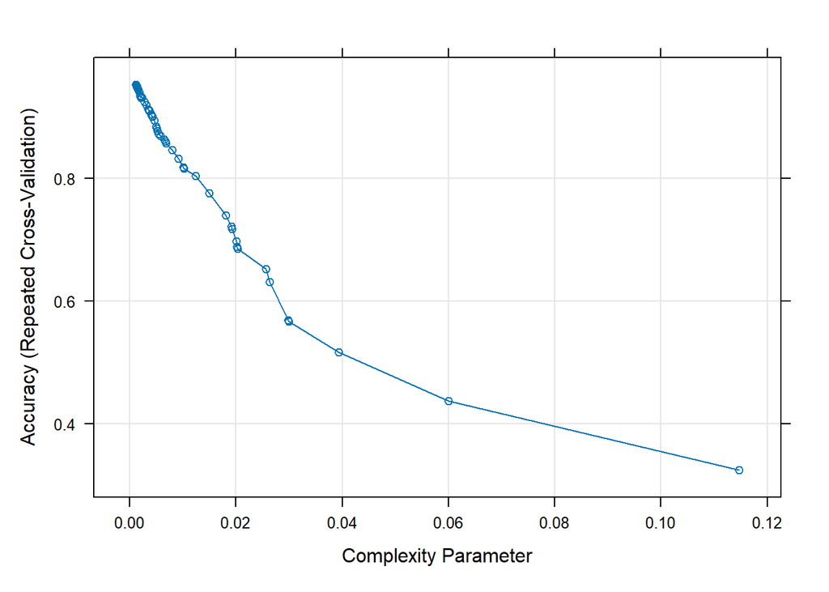

```r
plot(cvrpart)
```

## True Out-of-Set Accuracy

The test set outcomes were predicted using the model and entered into the quiz module to obtain accuracy.

```r
testpreds<-predict(cvrpart, newdata=test_small)
print(testpreds)
```

```
##  [1] B A B A A E D A A A C C B A E E A B B B
## Levels: A B C D E
```

2 predictions were wrong, all others were correct (90% true test set accuracy).